# Writing R Packages

Statistical Computing, 36-350

Friday August 2, 2019

# Logistics

- Final Exam
  - Shorter than homeworks (will be cumulative)
  - work by yourself, can only ask for help interpreting the questions
  - 5% extra credit on Final Exam if $>80\%$ of the class fills out FCEs
  - **more details Monday**
- Last week schedule
  - Monday & Tuesday like normal.
  - Wednesday Lecture: Tidyverse Advance: Split-Apply-Combine, Parallel Computing, and Deep Learning (?) -> **Optional**
  - Thursday: open work session (no need to attend)
  - Friday: Either a “lecture” where I bring in other phd students who talk about how they use computing in their research, or nothing…

# Last time: Version control

- version control (git) creates “snapshots” of your code with a message to help for future you
- Github is an example of a “centralized” version control tool (allows for easy sharing and collaboration.)
- “Github First” is the approach of making a github repo first before creating a directory on your computer (in Rstudio followed with making a project connected to the repo)
- `commit`s allow you to take a “snapshot” relative to new lines, modified lines, and deleted lines
- `push/pull` sends the snap shots on your computer to github or brings the snap shots from github to your computer (respectively)

# Why make an R Package?

- Packages are the “fundamental units of shareable code”
- Organization, standardized tools
- Fulfillment, building something

> “… from user to programmer to contributor, in the gradual progress that R encourages.”

> ~ John Chambers (Software for Data Analysis: Programming with R)

# R package: Goals

- Build a minimal working package
- Understand how `devtools`/ `usethis` can facilitate this process
- Develop a better understanding of how R packages work

# What is an R Package?

- Collection of files, organized in a specific way
- When installed by R, can be used in R sessions
- Packages are installed into libraries: see yours using `.libPaths()`
- Attached to the session using the `library()` function.

```r
library(tidyverse)
search()
```

```
##  [1] ".GlobalEnv"        "package:forcats"   "package:stringr"
##  [4] "package:dplyr"     "package:purrr"     "package:readr"
##  [7] "package:tidyr"     "package:tibble"    "package:ggplot2"
## [10] "package:tidyverse" "package:stats"     "package:graphics"
## [13] "package:grDevices" "package:utils"     "package:datasets"
## [16] "package:methods"   "Autoloads"         "package:base"
```

# The 5 stages of an R package

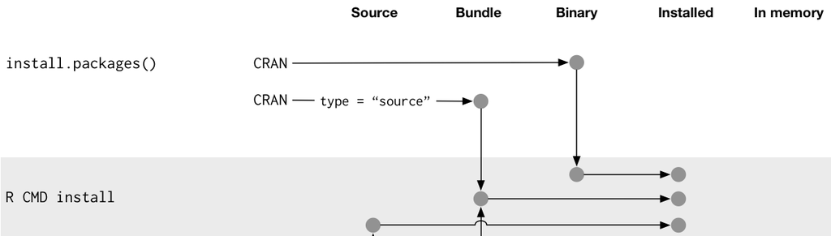

R provides tools (`R CMD INSTALL, R CMD BUILD, R CMD CHECK`, etc…) to move to different stages

# Packages to help with developing an R package

```r
library(devtools)
library(usethis)
# documentation
library(roxygen2)
# tests
library(testthat)
```

# `devtools` and `usethis` allows us to get our package up an running

“The goal of devtools is to make package development as painless as possible”

~ Hadley Wickham (R Packages)

```r
  install.packages("devtools")
  library("devtools")
```

- Provides a suite of functions which automate the higher level package details, which come with R itself

# Devtools serves as a wrapper to many other useful packages


# `usethis` focuses on automating repetitive tasks in building packages

```r
  install.packages("usethis")
  library("usethis")
```

“usethis is a workflow package: it automates repetitive tasks that arise during project setup and development, both for R packages and non-package projects.”

~ `usethis` package description

# Step 0: Setting up your github (“Github First”)

Just like in the version control we are going to us the “Github First” Approach. Here are the reminder of the steps:

**In `GitHub`, do the following:**

- go to the top-level directory (i.e., `github.com/<your user name>`)
- click on “+” at top right, and select “New repository”
- name the repository (e.g., “tartan”)
- provide a short description of the repository (don’t leave completely blank!)
- keep the repository public (as students you have access to free private repos https://education.github.com/pack, but for purposes of this lab keep the repo public)
- click on “Initialize this repository with a README” and select the R option in “Add .gitignore”… there is no need to “Add a license”
- click on “Create Repository”

**…then RStudio**

In **RStudio**, do the following:

- click on `File > New Project…`
- click on “Version Control”, then on “Git”
- provide the *full* address for the “Repository URL” (including the `https`, etc.; by default, this will provide the name of your local repository)
- make sure “Create project as subdirectory of:” points to where you want to point it
- click on “Create Project” (in this example we will be calling our package `tartan`)

# Step 1: Create the minimal source package

An R (*source*) package is just files in a directory, formatted in a specific way.

To create the bare bones R package, just type:

```r
usethis::create_package("tartan")
```

- if in the `tartan` project, may need to do `setwd("../")`, run the above line and then do `setwd("tartan")`.

This should give us:

1. Directory `R/`
2. Directory `man/`
3. `NAMESPACE` file
4. `DESCRIPTION` file
5. `tartan.Rproj` file (if using RStudio)

and anything else you included from intializing your git repo (`.gitignore`, `LICENSE`, etc)

# The description file contains package meta-data

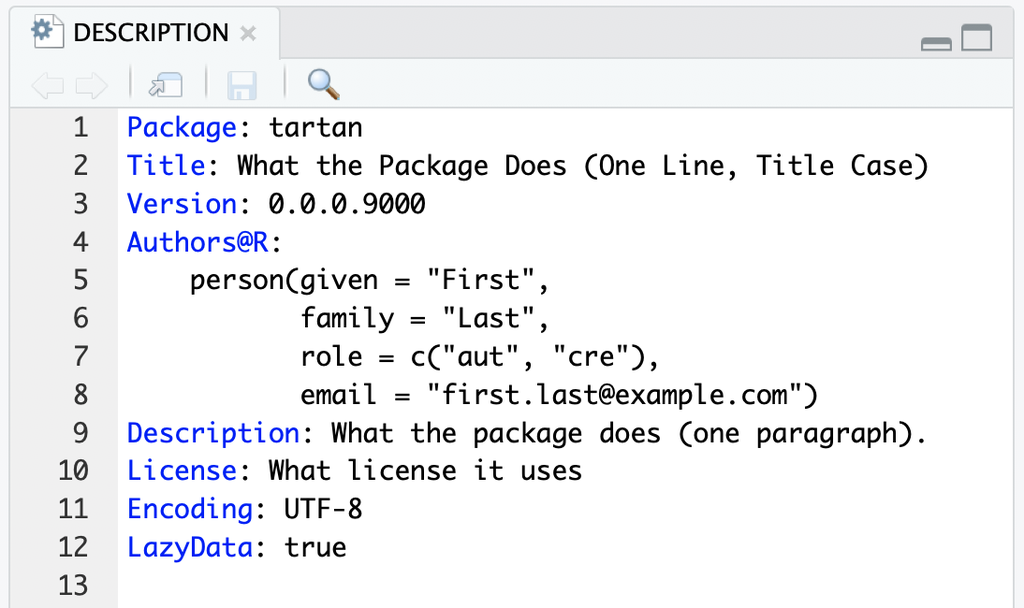

`usethis` creates the “bare minimum” description file

This is fine for now, but becomes more important when you want to release your package

# Step 2: Writing a function

All of your R code goes into the `R/` directory. Generally, this code is made up of functions

For example, lets create the file `R/welcome.R` and add the function:

```r
usethis::use_r("welcome") # opens up file (creates if need be)
```

```r
call_scotty_demo <- function(your_name) {
  if (nchar(your_name) > 30){
    warning("your name is beyond 30 characters, and has been truncated")
    your_name <- substr(your_name, 1, 30)
  }

  name_length <- nchar(your_name)

  # Hiiiii
  cat(paste("\n",
    paste0(c("", rep("-", name_length + 8), "\n"), collapse = ""),
    paste0(c("| Hi ", your_name, "! | \n"), collapse=""),
    paste0(c("|   ", rep("-", name_length + 4), "\n"), collapse = ""),
    paste0(c("| /\n")))
  )

  # from Scotty.
  cat(paste0(
      " |/  |\\_/|          \n",
      " |   |q p|   /}      \n",
      " |   ( 0 )\"\"\"\\   \n",
      "  \\  |\"-\"`    |    \n",
      "     || /=\\\\  |     \n",
      "     \"'\"  '\"\"\"'"))

}
```

Now, we can load the package into memory:

```r
devtools::load_all()
```

# More on devtools::load_all()

`devtools::load_all()` loads your source package into memory

This is important because in developing a package, you often need to re-install the package over and over

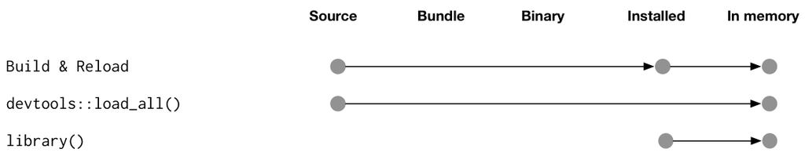

Contrasting with the `library()` function, which loads (then attaches) already installed packages

# Step 2: Documentation our functions

- R comes with tools for documentation (`?sum`)
- You can utilize these tools by storing `.Rd` files in a `man/` directory. The `.Rd` look a bit like LaTex
- R renders these files into html, pdf, or whichever format is needed.

# Devtools connects with roxygen2 for more convinient documentation

The easiest way to document your R code is `roxygen2` package (😱 which we already learned how to use - *how useful*).

Primarily, this allows you to combine code and documentation into a single file, and handles the `.Rd` formatting (and NAMESPACE) for you

```r
install.packages("roxygen2")
library(roxygen2)
```

# With roxygen2, we write documentation on top of the function

```r
#' Meet Scotty, the Scottie Dog
#'
#' @param your_name string of your name (max length 30 characters)
#'
#' @return NULL. Though scotty appears on your screen and says Hi to you.
#' @export
#'
#' @examples
#' call_scotty_demo("Andrew Carnegie")
call_scotty_demo <- function(your_name) {

  if (nchar(your_name) > 30){
    warning("your name is beyond 30 characters, and has been truncated")
    your_name <- substr(your_name, 1, 30)
  }

  name_length <- nchar(your_name)

  # Hiiiii
  cat(paste("\n",
    paste0(c("", rep("-", name_length + 8), "\n"), collapse = ""),
    paste0(c("| Hi ", your_name, "! | \n"), collapse=""),
    paste0(c("|   ", rep("-", name_length + 4), "\n"), collapse = ""),
    paste0(c("| /\n")))
  )

  # from Scotty.
  cat(paste0(
      " |/  |\\_/|          \n",
      " |   |q p|   /}      \n",
      " |   ( 0 )\"\"\"\\   \n",
      "  \\  |\"-\"`    |    \n",
      "     || /=\\\\  |     \n",
      "     \"'\"  '\"\"\"'"))

}
```

# Creating Documentation

As a standard workflow, we can use:

```r
devtools::document()
```

- This creates a `man/` folder, and insert the corresponding `man/call_scotty_demo.Rd` file that R uses to generate documentation.
- It also updates the `NAMESPACE` file so when you load your functions you get the desired documenation (need to have `@export`)

# Let’s see what this looks like:

```r
% Generated by roxygen2: do not edit by hand
% Please edit documentation in R/welcome.R
\name{call_scotty_demo}
\alias{call_scotty_demo}
\title{Meet Scotty, the Scottie Dog}
\usage{
call_scotty_demo(your_name)
}
\arguments{
\item{your_name}{string of your name (max length 30 characters)}
}
\value{
\code{NULL}. Though scotty appears on your screen and says Hi to you.
}
\description{
Meet Scotty, the Scottie Dog
}
\examples{
call_scotty_demo("Andrew Carnegie")
}
```

# We can now view our documentation in the standard R format

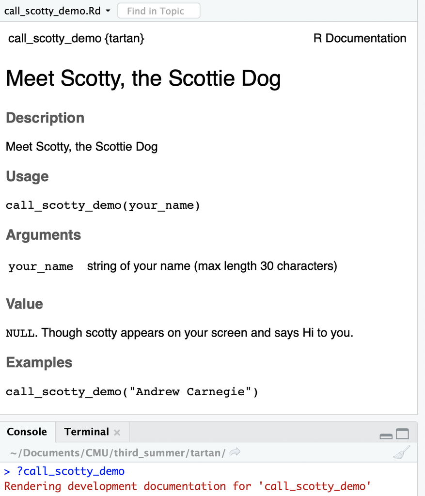

```r
devtools::load_all()
?call_scotty_demo
```

# Step 4: Testing

Testing is critical to making sure your packages do what you expect.

The easiest way to get started with testing is the `testthat` package, which also integrates with `devtools`

```r
install.packages("testthat")
usethis::use_testthat()
```

This will set up the `tests/testthat` directory where we can store tests

# How does `testthat` work?

Test-that works hierarchically:

1. Expectation: Fundamental unit of testing. They describe what result is expected of your various computations. We can use these to make sure our functions are giving the expected output.

```r
  library(testthat)
  expect_equal(1, 1)
  expect_equal(1, 2)
```

```
## Error: 1 not equal to 2.
## 1/1 mismatches
## [1] 1 - 2 == -1
```

2. Test: Group of Expectations

```r
test_that(paste("calling scotty works well (returns null",
                 "and provides warning nchar > 30)"), {
  expect_equal(call_scotty_demo("Oski Bear"), NULL)
  expect_warning(call_scotty_demo("Oski Bear, your a wonderful, but slightly creepy Berkeley Bear"))
  expect_equal(1, 2)
})
```

```
##
##  -----------------
##  | Hi Oski Bear! |
##  |   -------------
##  | /
##  |/  |\_/|
##  |   |q p|   /}
##  |   ( 0 )"""\
##   \  |"-"`    |
##      || /=\\  |
##      "'"  '"""'
##  --------------------------------------
##  | Hi Oski Bear, your a wonderful, b! |
##  |   ----------------------------------
##  | /
##  |/  |\_/|
##  |   |q p|   /}
##  |   ( 0 )"""\
##   \  |"-"`    |
##      || /=\\  |
##      "'"  '"""'
```

```
## Error: Test failed: 'calling scotty works well (returns null and provides warning nchar > 30)'
## * 1 not equal to 2.
## 1/1 mismatches
## [1] 1 - 2 == -1
```

3. File: File which contains tests. Must start with `test`

# Testing our function

Next, let’s create a file `tests/testthat/test-welcome.R`

```r
usethis::use_test("welcome")
```

```r
✔ Setting active project to './tartan'
✔ Adding 'testthat' to Suggests field in DESCRIPTION
✔ Creating 'tests/testthat/'
✔ Writing 'tests/testthat.R'
✔ Writing 'tests/testthat/test-welcome.R'
● Modify 'tests/testthat/test-welcome.R'
```

What we put in the `test-welcome.R` file:

```r
context("test welcome from scotty")

test_that(paste("calling scotty works well (returns null",
                 "and provides warning nchar > 30)"), {
  expect_equal(call_scotty_demo("Oski Bear"), NULL)
  expect_warning(call_scotty_demo("Oski Bear, your a wonderful, but slightly creepy Berkeley Bear"))
  expect_equal(1, 2)
})
```

Now run:

```r
devtools::test()
```

# Example output from `testthat`:

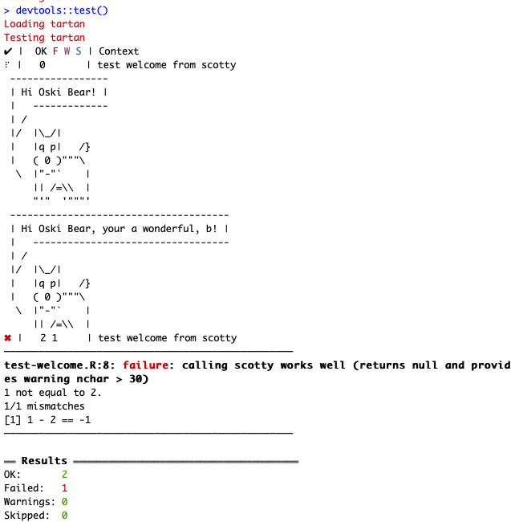

# Step 5: Syncronizing with Github

This allows users to install your package without being hosted on CRAN.

For example, you could install the R package I just made using:

```r
devtools::install_github(repo = "benjaminleroy/tartan",
                         force = F)
# so making the sides does do it a ton of times
library(tartan)
#?call_scotty_demo
call_scotty_demo("Big Bird")
```

```
##
##  ----------------
##  | Hi Big Bird! |
##  |   ------------
##  | /
##  |/  |\_/|
##  |   |q p|   /}
##  |   ( 0 )"""\
##   \  |"-"`    |
##      || /=\\  |
##      "'"  '"""'
```

Remarkably, the package is available to everyone with an internet connection

# Instructions for syncronizing with Github

Remember, now that we’ve done the basics we can use Rstudio’s built in git and connect to Github to commit all changes and push to Github.

Now check out the Github page, all of the code is there!

Congratulations! You now have your own personal R Package

# There are many more great features of to look into, including:

- Including data (can be [documented](http://r-pkgs.had.co.nz/data.html) too)

  ```r
  # suppose that I have a tarans dataset that I created - than I can save it this way
  usethis::use_data(tartans)
  # and document at
  usethis::use_r("data")
  ```

- Vignettes (long form documentation, knitr)
- Compiled code (C, C++, Fortran…)
- creating a CRAN ready package
- explore all the things that [`usethis`](https://usethis.r-lib.org/reference/index.html) automates.

# Summary

- `devtools` (high level development tools) useful functions:
  - `devtools::load()`: load package into global environment
  - `devtools::document()`: document functions
  - `devtools::test()`: run tests of functions
- `usethis` (automation): set of desirable functions including `use_r` to open up or create a new function file in `R/` (similar for `use_test`).
- `roxygen2` (commenting): make desirable documentation
- packaging you code consists mostly of
  - creating the package
  - writing functions (and documenting them)
  - writing tests (`testthat`)
  - updating package and sharing it with `git` and `github`

# Final comments:

You don’t have to do use the “Github first”, you can find other resources online about how to connect a package to github after you make it (using `usethis` even).

# Good Resources:

- [R Packages](http://r-pkgs.had.co.nz). Hadley Wickham
- [Software for Data Analysis: Programming with R.](https://link.springer.com/book/10.1007/978-0-387-75936-4) John Chambers
- [Writing R Extensions](https://cran.r-project.org/doc/manuals/r-release/R-exts.html) (the official documentation)